# Statistical Tests

Antonio Osamu Katagiri Tanaka - A01212611@itesm.mx

March 27, 2020

```r
# Clear all objects (from the workspace)
rm(list = ls())

# Suppress Warning messages
options(warn = -1)

# Turn off scientific notation like 1e+06
# options(scipen=999)

# # INSTALL packages
# if (!requireNamespace("BiocManager", quietly = TRUE))
#   install.packages("BiocManager")
# BiocManager::install("impute")

# Load Libs
library(DT)
library(samr)
library(affy)
library(GEOquery)
```

[output not shown]

# 1) Obtener p-values con un t-test, Wilcoxon y Kolmogorov para:

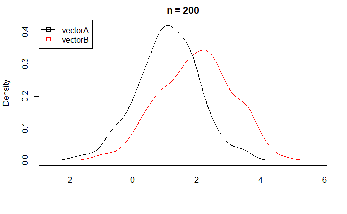

[figure not shown]

```r
getPvalues <- function(dist) {
  ns = 2:200
  ttest_pval = c()
  wtest_pval = c()
  ktest_pval = c()

  for (n in ns) {
    if (dist == "rnorm") {
      vectorA = rnorm(n = n, mean = 1, sd = 1)
      vectorB = rnorm(n = n, mean = 2, sd = 1)
    } else {
      vectorA = runif(n, -1, 1)
      vectorB = runif(n, -1, 1)
    }

    if (n == max(ns)) {
      plot.densities(vectorA, vectorB, main = paste0("n = ", n))
    }

    ttest = t.test(vectorA, vectorB)
    ttest_pval = c(ttest_pval, ttest$p.value)
    #print(ttest$p.value)

    wtest = wilcox.test(vectorA, vectorB)
    wtest_pval = c(wtest_pval, wtest$p.value)
    #print(wtest$p.value)

    ktest = ks.test(vectorA, vectorB)
    ktest_pval = c(ktest_pval, ktest$p.value)
    #print(ktest$p.value)
  }

  if (dist == "rnorm") {
    plot(
      ns,
      ttest_pval,
      main = "rnorm",
      xlab = "n",
      ylab = "p.value",
      type = "l",
      col = "blue",
      log = "x"
    )
  } else {
    plot(
      ns,
      ttest_pval,
      main = "runif",
      xlab = "n",
      ylab = "p.value",
      type = "l",
      col = "blue"
    )
  }

  lines(ns, wtest_pval,
        col = "red")

  lines(ns, ktest_pval,
        col = "green")

  legend("topright",
         c("t.test", "wilcox.test", "ks.test"),
         fill = c("blue", "red", "green"))
}

getPvalues("rnorm")
```

## B) Repetir (A) con 2 vectores de datos generados con la función runif.

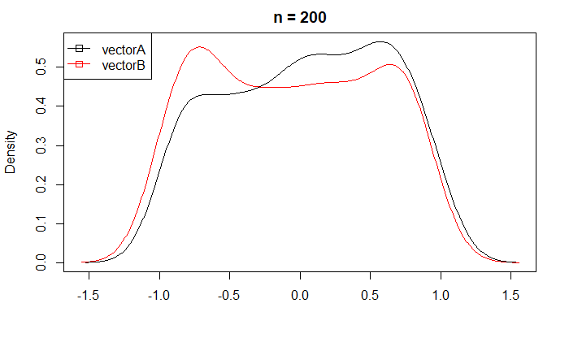

[figure not shown]

```r
getPvalues("runif")
```

# 2) Obtener p-values con un t-test, Wilcoxon, Kolmogorov y SAM para una base de datos GEO de su elección.

```r
calPvalues <- function(data.matrix, lvls) {
  pval = de.test(
    x = data.matrix,
    classes = lvls,
    test = c("ttest", "kolmogorov", "wilcoxon")
  )
  data.matrix_sam <- sam(data.matrix,
                         c(rep(1, dim(data.matrix)[2])),
                         method = "d.stat",
                         gene.names = colnames(data.matrix))

  return(
    list(
      "ttest_pval" = pval$ttest,
      "wtest_pval" = pval$kolmogorov,
      "ktest_pval" = pval$wilcoxon,
      "sam_pval"   = unname(data.matrix_sam@p.value)
    )
  )
}

plt_pval <- function(pval) {
  for (i in 1:length(pval)) {
    ns = 1:length(pval[[i]])
    plot(
      ns,
      pval[[i]],
      main = "runif",
      xlab = "",
      ylab = "p.value",
      #log = "y",
      col = "blue",
      type = "p"
    )
  }
}
```

### Dataset details

**Title:** Lung response to highly virulent or low virulent influenza A H3N2 virus infection: time course

**Summary:** Analysis of total lung from BALB/c females infected with highly virulent influenza A (HVI) or low virulent influenza A (LVI), up to 96 hrs following infection. Results provide insight into the molecular mechanisms underlying the host pulmonary responses to HVI and LVI infections.

**Organism:** Mus musculus

**Platform:** GPL6103: Illumina mouseRef-8 v1.1 expression beadchip

**Citation:** Ivan FX, Rajapakse JC, Welsch RE, Rozen SG et al. Differential pulmonary transcriptomic profiles in murine lungs infected with low and highly virulent influenza H3N2 viruses reveal dysregulation of TREM1 signaling, cytokines, and chemokines. Funct Integr Genomics 2012 Mar;12(1):105-17. PMID: 21874528

**Reference Series:** GSE55994

**Sample count:** 18

**Value type:** transformed count

**Series published:** 2014/03/19

**Dataset taken from:** [ncbi.nlm.nih.gov](https://www.ncbi.nlm.nih.gov/geo/query/acc.cgi?acc=GSE55994)

Let’s compare influenza A H3N2 infection levels. (from GSE55994)

```r
# Download GDS file, put it in the current directory, and load it
gds5159 <- getGEO('GDS5159', destdir='./NCBI_GEO')
```

```
Using locally cached version of GDS5159 found here:
./NCBI_GEO/GDS5159.soft.gz
```

```r
eset <- GDS2eSet(gds5159, do.log2 = TRUE)  # Convert the data to ESET object
```

```
File stored at:
C:\Users\oskat\AppData\Local\Temp\RtmpQfbhnH/GPL6103.annot.gz
1 parsing failure.
  row     col               expected                     actual         file
21574 Gene ID no trailing characters ///665506///621968///21580 literal data
```

```r
pData(eset)$infection         # Let's check at the infections
```

```
 [1] mock                        mock                        mock
 [4] mock                        mock                        mock
 [7] low virulent influenza A    low virulent influenza A    low virulent influenza A
[10] low virulent influenza A    low virulent influenza A    low virulent influenza A
[13] highly virulent influenza A highly virulent influenza A highly virulent influenza A
[16] highly virulent influenza A highly virulent influenza A highly virulent influenza A
Levels: highly virulent influenza A low virulent influenza A mock
```

```r
table(pData(eset)$infection)  # No. of samples in each infection
```

```
highly virulent influenza A    low virulent influenza A                        mock
                          6                           6                           6
```

Filter columns associated with ‘highly virulent influenza A’ and ‘mock’ values.

```r
selected <- grep("mock|highly virulent influenza A", pData(eset)$infection) # Select indexes
pData(eset)$infection[selected] # Check selection
```

```
 [1] mock                        mock                        mock
 [4] mock                        mock                        mock
 [7] highly virulent influenza A highly virulent influenza A highly virulent influenza A
[10] highly virulent influenza A highly virulent influenza A highly virulent influenza A
Levels: highly virulent influenza A low virulent influenza A mock
```

```r
y <- c(rep(1, 6), rep(2, 6))  # Vector of levels ID
y
```

```
 [1] 1 1 1 1 1 1 2 2 2 2 2 2
```

## A) Verifique si necesita normalizar los datos con quantile normalization. Obtenga p-values antes y después de normalizar.

Filter the expression matrix according to selected, then quantile normalize

[There is small-to-large variability within groups and small variability across groups, so, let’s use quantile normalization]

```r
# Get a subset of expression values of the selected samples
exprs.selected <- exprs(eset)[, selected]
plot.densities(exprs.selected, main = "BEFORE quantile.normalization", legend.pos="topright")
```

[output not shown]

```r
# p values before quantile normalize
pval = calPvalues(exprs.selected,y)
```

[output not shown]

```
We're doing 4096 complete permutations
and randomly select 100 of them.
```

```
The spline based estimation of pi0 results in a non-positive value of pi0.
Therefore, pi0 is estimated by using lambda = 0.5.
```

```r
exprs.selected.q <- normalizeQuantiles(exprs.selected)  # Quantile normalize the data
plot.densities(exprs.selected.q, main = "AFTER quantile.normalization", legend.pos="topright")
```

[output not shown]

```r
# p values after quantile normalize
pval.q = calPvalues(exprs.selected.q,y)
```

[output not shown]

```
We're doing 4096 complete permutations
and randomly select 100 of them.
```

```
The spline based estimation of pi0 results in a non-positive value of pi0.
Therefore, pi0 is estimated by using lambda = 0.5.
```

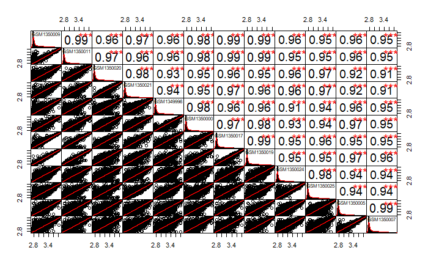

```r
chart.Correlation(
  exprs.selected.q,
  histogram = TRUE
)
```

Let’s prepare the data that required to run **samr()**

```r
# Get row names = gene names or IDs
genenames <- rownames(exprs(eset))
data <- list(
  x = exprs.selected.q,
  y = y,
  geneid = genenames,
  genenames = genenames,
  logged2 = TRUE
)
```

Refer to help(samr) for more info.

```r
# Get object names from samr.obj
samr.obj <-
  samr(data, resp.type = "Two class unpaired", nperms = 100)
```

[output not shown]

[output cut: 45 more lines]

[output not shown]

```r
names(samr.obj)
```

```
 [1] "n"                    "x"                    "xresamp"
 [4] "y"                    "argy"                 "censoring.status"
 [7] "testStatistic"        "nperms"               "nperms.act"
[10] "tt"                   "numer"                "sd"
[13] "sd.internal"          "s0"                   "s0.perc"
[16] "evo"                  "perms"                "permsy"
[19] "nresamp"              "nresamp.perm"         "all.perms.flag"
[22] "ttstar"               "ttstar0"              "eigengene"
[25] "eigengene.number"     "pi0"                  "foldchange"
[28] "foldchange.star"      "sdstar.keep"          "resp.type"
[31] "resp.type.arg"        "assay.type"           "stand.contrasts"
[34] "stand.contrasts.star" "stand.contrasts.95"   "depth"
[37] "call"
```

Compute thresholds for different deltas

```r
delta <- 1.2 # define the delta
delta.table <- samr.compute.delta.table(samr.obj, min.foldchange = delta)
```

[output not shown]

```r
# Look at the whole delta table
datatable(delta.table)
```

| delta | # med false pos | 90th perc false pos | # called | median FDR | 90th perc FDR | cutlo | cuthi |
| --- | --- | --- | --- | --- | --- | --- | --- |
| 0 | 2.77414374517531 | 11.3739893552188 | 54 | 0.0513730323180614 | 0.210629432504052 | -1.74810434357576 | 1.6775552443206 |
| 0.000968650282736261 | 2.77414374517531 | 11.3739893552188 | 54 | 0.0513730323180614 | 0.210629432504052 | -1.74810434357576 | 1.6775552443206 |
| 0.00387460113094504 | 2.77414374517531 | 11.3739893552188 | 54 | 0.0513730323180614 | 0.210629432504052 | -1.74810434357576 | 1.6775552443206 |
| 0.00871785254462635 | 2.77414374517531 | 11.3739893552188 | 54 | 0.0513730323180614 | 0.210629432504052 | -1.74810434357576 | 1.6775552443206 |
| 0.0154984045237802 | 2.77414374517531 | 11.3739893552188 | 54 | 0.0513730323180614 | 0.210629432504052 | -1.74810434357576 | 1.6775552443206 |
| 0.0242162570684065 | 2.77414374517531 | 11.3739893552188 | 54 | 0.0513730323180614 | 0.210629432504052 | -1.74810434357576 | 1.6775552443206 |
| 0.0348714101785054 | 2.77414374517531 | 11.3739893552188 | 54 | 0.0513730323180614 | 0.210629432504052 | -1.74810434357576 | 1.6775552443206 |
| 0.0474638638540768 | 2.77414374517531 | 11.3739893552188 | 54 | 0.0513730323180614 | 0.210629432504052 | -1.74810434357576 | 1.6775552443206 |
| 0.0619936180951207 | 2.77414374517531 | 11.3739893552188 | 54 | 0.0513730323180614 | 0.210629432504052 | -1.74810434357576 | 1.6775552443206 |
| 0.0784606729016372 | 2.77414374517531 | 11.3739893552188 | 54 | 0.0513730323180614 | 0.210629432504052 | -1.74810434357576 | 1.6775552443206 |

[output cut: 40 more lines]

Let’s select delta with median FDR <10%.

```r
# Check delta related to median FDR of 0.1
delta.table[delta.table[, "median FDR"] < 0.1,][1,]
```

```
              delta     # med false pos 90th perc false pos            # called
         0.00000000          2.77414375         11.37398936         54.00000000
         median FDR       90th perc FDR               cutlo               cuthi
         0.05137303          0.21062943         -1.74810434          1.67755524
```

```r
samr.plot(samr.obj, delta)  # Check SAM plot
```

[output not shown]

## B) Comente sobre la cantidad de genes significativos.

### Get significant genes

```r
siggenes.table <- samr.compute.siggenes.table(samr.obj,
                                              delta,
                                              data,
                                              delta.table,
                                              min.foldchange = delta)

datatable(siggenes.table$genes.lo)  # Check how table with the results look like
```

| Row | Gene ID | Gene Name | Score(d) | Numerator(r) | Denominator(s+s0) | Fold Change | q-value(%) |
| --- | --- | --- | --- | --- | --- | --- | --- |

```r
datatable(siggenes.table$genes.up)  # Check how table with the results look like
```

| Row | Gene ID | Gene Name | Score(d) | Numerator(r) | Denominator(s+s0) | Fold Change | q-value(%) |
| --- | --- | --- | --- | --- | --- | --- | --- |
| 16314 | ILMN_2763243 | ILMN_2763243 | 6.77045829674065 | 0.500645010330988 | 0.0739455127538416 | 1.41484598036509 | 0 |
| 16859 | ILMN_2772632 | ILMN_2772632 | 5.90318005355945 | 0.453304298362458 | 0.0767898478870094 | 1.36917257338006 | 0 |
| 20749 | ILMN_2769917 | ILMN_2769917 | 5.36573836049137 | 0.460717358143325 | 0.0858628071647411 | 1.37622595543983 | 0 |
| 17788 | ILMN_2591265 | ILMN_2591265 | 5.24181740583111 | 0.28403474372971 | 0.05418631015528 | 1.21759534107198 | 0 |
| 24526 | ILMN_1246800 | ILMN_1246800 | 4.7570649235383 | 0.294288593643489 | 0.0618634806069869 | 1.22628013798711 | 0 |
| 13079 | ILMN_2702303 | ILMN_2702303 | 4.46658048188941 | 0.286387767044293 | 0.064117901424928 | 1.21958284905855 | 0 |
| 17953 | ILMN_2771766 | ILMN_2771766 | 4.42236050906219 | 0.292311422203738 | 0.066098505900806 | 1.2246007079222 | 0 |
| 1835 | ILMN_2595732 | ILMN_2595732 | 4.42122076791449 | 0.282670569382864 | 0.0639349591936801 | 1.21644455921938 | 0 |
| 11691 | ILMN_2771176 | ILMN_2771176 | 4.3429845676493 | 0.488089114442603 | 0.112385643292025 | 1.40258588488981 | 0 |
| 17748 | ILMN_1225204 | ILMN_1225204 | 4.24130709678923 | 0.314798789689812 | 0.0742221165565027 | 1.24383816513269 | 0 |

[output cut: 7 more lines]

# 3) Repetir el ejercicio (2) pero con una base de datos de GEO con menos o más muestras, según sea el caso.

Let’s compare lung cells related gene expressions due to different bacterial strains. (from GDS858=

```r
# Download GDS file, put it in the current directory, and load it
gds858 <- getGEO('GDS858', destdir='./NCBI_GEO')
```

```
Using locally cached version of GDS858 found here:
./NCBI_GEO/GDS858.soft.gz
```

```r
eset <- GDS2eSet(gds858, do.log2 = TRUE)  # Convert the data to ESET object
```

[output not shown]

```r
pData(eset)$infection         # Let's check at the infections
```

```
 [1] uninfected uninfected uninfected uninfected FRD875     FRD875     FRD875     FRD875
 [9] FRD1234    FRD1234    FRD1234    FRD1       FRD1       FRD1       FRD1       FRD440
[17] FRD440     FRD440     FRD440
Levels: FRD1 FRD1234 FRD440 FRD875 uninfected
```

```r
table(pData(eset)$infection)  # No. of samples in each infection
```

```
      FRD1    FRD1234     FRD440     FRD875 uninfected
         4          3          4          4          4
```

Filter columns associated with ‘uninfected’ and ‘FRD440’ values.

```r
selected <- grep("uninfected|FRD440", pData(eset)$infection) # Select indexes
pData(eset)$infection[selected]                              # Check selection
```

```
[1] uninfected uninfected uninfected uninfected FRD440     FRD440     FRD440     FRD440
Levels: FRD1 FRD1234 FRD440 FRD875 uninfected
```

‘Uninfected’ as ‘1’s and ’FRD440’ ’2’s

```r
y <- c(rep(1, 4), rep(2, 4))  # Vector of levels ID
y
```

```
[1] 1 1 1 1 2 2 2 2
```

## A) Verifique si necesita normalizar los datos con quantile normalization. Obtenga p-values antes y después de normalizar.

Filter the expression matrix according to selected, then quantile normalize

[There is small-to-large variability within groups and small variability across groups, so, let’s use quantile normalization]

```r
# Get a subset of expression values of the selected samples
exprs.selected <- exprs(eset)[, selected]
plot.densities(exprs.selected, main = "BEFORE quantile.normalization")
```

[output not shown]

```r
# p values before quantile normalize
pval = calPvalues(exprs.selected,y)
```

[output not shown]

```
We're doing 256 complete permutations
and randomly select 100 of them.
```

```
The spline based estimation of pi0 results in a non-positive value of pi0.
Therefore, pi0 is estimated by using lambda = 0.5.
```

```r
exprs.selected.q <- normalizeQuantiles(exprs.selected)  # Quantile normalize the data
plot.densities(exprs.selected.q, main = "AFTER quantile.normalization")
```

[output not shown]

```r
# p values after quantile normalize
pval.q = calPvalues(exprs.selected.q,y)
```

[output not shown]

```
We're doing 256 complete permutations
and randomly select 100 of them.
```

```
The spline based estimation of pi0 results in a non-positive value of pi0.
Therefore, pi0 is estimated by using lambda = 0.5.
```

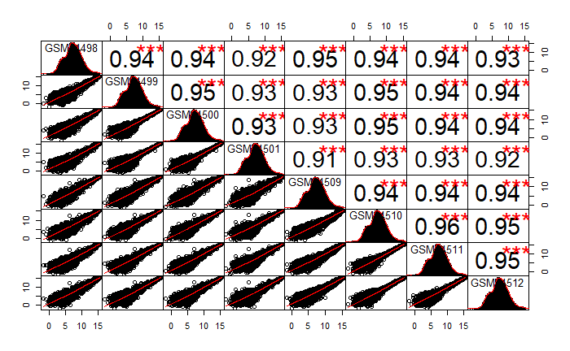

```r
chart.Correlation(
  exprs.selected.q,
  histogram = TRUE
)
```

Let’s prepare the data that required to run **samr()**

```r
# Get row names = gene names or IDs
genenames <- rownames(exprs(eset))
data <- list(
  x = exprs.selected.q,
  y = y,
  geneid = genenames,
  genenames = genenames,
  logged2 = TRUE
)
```

Refer to help(samr) for more info.

```r
# Get object names from samr.obj
samr.obj <-
  samr(data, resp.type = "Two class unpaired", nperms = 100)
```

[output not shown]

[output cut: 45 more lines]

[output not shown]

```r
names(samr.obj)
```

```
 [1] "n"                    "x"                    "xresamp"
 [4] "y"                    "argy"                 "censoring.status"
 [7] "testStatistic"        "nperms"               "nperms.act"
[10] "tt"                   "numer"                "sd"
[13] "sd.internal"          "s0"                   "s0.perc"
[16] "evo"                  "perms"                "permsy"
[19] "nresamp"              "nresamp.perm"         "all.perms.flag"
[22] "ttstar"               "ttstar0"              "eigengene"
[25] "eigengene.number"     "pi0"                  "foldchange"
[28] "foldchange.star"      "sdstar.keep"          "resp.type"
[31] "resp.type.arg"        "assay.type"           "stand.contrasts"
[34] "stand.contrasts.star" "stand.contrasts.95"   "depth"
[37] "call"
```

Compute thresholds for different deltas

```r
delta <- 1.9 # define the delta
delta.table <- samr.compute.delta.table(samr.obj, min.foldchange = delta)
```

[output not shown]

```r
# Look at the whole delta table
datatable(delta.table)
```

| delta | # med false pos | 90th perc false pos | # called | median FDR | 90th perc FDR | cutlo | cuthi |
| --- | --- | --- | --- | --- | --- | --- | --- |
| 0 | 1192.91082888301 | 1408.35463806489 | 1671 | 0.71389038233573 | 0.842821447076537 | -0.647430045547494 | 0.697219939439642 |
| 0.00268653464601614 | 1192.91082888301 | 1408.35463806489 | 1671 | 0.71389038233573 | 0.842821447076537 | -0.647430045547494 | 0.697219939439642 |
| 0.0107461385840646 | 1192.91082888301 | 1408.35463806489 | 1671 | 0.71389038233573 | 0.842821447076537 | -0.647430045547494 | 0.697219939439642 |
| 0.0241788118141453 | 1192.91082888301 | 1408.35463806489 | 1671 | 0.71389038233573 | 0.842821447076537 | -0.647430045547494 | 0.697219939439642 |
| 0.0429845543362583 | 1192.91082888301 | 1408.35463806489 | 1671 | 0.71389038233573 | 0.842821447076537 | -0.647430045547494 | 0.697219939439642 |
| 0.0671633661504036 | 1192.91082888301 | 1408.35463806489 | 1671 | 0.71389038233573 | 0.842821447076537 | -0.647430045547494 | 0.697219939439642 |
| 0.0967152472565812 | 1192.91082888301 | 1408.35463806489 | 1671 | 0.71389038233573 | 0.842821447076537 | -0.647430045547494 | 0.697219939439642 |
| 0.131640197654791 | 1163.34515101198 | 1384.87349100211 | 1644 | 0.707630870445245 | 0.842380468979385 | -0.794041886911201 | 0.868635067296319 |
| 0.171938217345033 | 1028.37140420949 | 1251.18520845488 | 1488 | 0.691109814656913 | 0.840850274499245 | -1.00139002578493 | 1.07181191894449 |
| 0.217609306327308 | 797.844814432527 | 1012.94583314634 | 1236 | 0.645505513294925 | 0.819535463710635 | -1.20681750010438 | 1.31111178016907 |

[output cut: 40 more lines]

Let’s select delta with median FDR <10%.

```r
# Check delta related to median FDR of 0.1
delta.table[delta.table[, "median FDR"] < 0.1,][1,]
```

```
              delta     # med false pos 90th perc false pos            # called
         1.42117683          3.42790468          6.85580936         37.00000000
         median FDR       90th perc FDR               cutlo               cuthi
         0.09264607          0.18529214         -5.91083339          4.29822435
```

```r
samr.plot(samr.obj, delta)  # Check SAM plot
```

[output not shown]

## B) Comente sobre la cantidad de genes significativos.

### Get significant genes

```r
# Summarize
siggenes.table <- samr.compute.siggenes.table(samr.obj,
                                              delta,
                                              data,
                                              delta.table,
                                              min.foldchange = delta)

datatable(siggenes.table$genes.lo)  # Check how table with the results look like
```

| Row | Gene ID | Gene Name | Score(d) | Numerator(r) | Denominator(s+s0) | Fold Change | q-value(%) |
| --- | --- | --- | --- | --- | --- | --- | --- |
| 14069 | 214692_s_at | 214692_s_at | -8.50617104840418 | -3.62955195559847 | 0.42669632845902 | 0.0807971404364847 | 3.89534622806624 |
| 15033 | 215659_at | 215659_at | -7.39961498615012 | -2.53948326562867 | 0.34319127013795 | 0.172004323535609 | 3.89534622806624 |

```r
datatable(siggenes.table$genes.up)  # Check how table with the results look like
```

| Row | Gene ID | Gene Name | Score(d) | Numerator(r) | Denominator(s+s0) | Fold Change | q-value(%) |
| --- | --- | --- | --- | --- | --- | --- | --- |
| 3356 | 203828_s_at | 203828_s_at | 12.7306592719215 | 3.82917455857621 | 0.300783681095114 | 14.2133483704722 | 0 |
| 6722 | 207196_s_at | 207196_s_at | 8.15319831291686 | 1.70708362956261 | 0.209375948437086 | 3.26500144340122 | 0 |
| 16212 | 216841_s_at | 216841_s_at | 7.81296600184981 | 2.33033953287497 | 0.298265669186738 | 5.02923697090547 | 0 |
| 3948 | 204420_at | 204420_at | 7.7778136546489 | 1.46234052049765 | 0.188014342516884 | 2.75555041084664 | 0 |
| 2039 | 202510_s_at | 202510_s_at | 7.63293710482856 | 2.52750740656639 | 0.33113169568337 | 5.7657464946743 | 0 |
| 2388 | 202859_x_at | 202859_x_at | 6.85934644804566 | 2.05505726711766 | 0.299599573032673 | 4.15560136460615 | 0 |
| 5418 | 205890_s_at | 205890_s_at | 6.74959784875184 | 2.10594719020738 | 0.312010765292753 | 4.30480291911734 | 0 |
| 2167 | 202638_s_at | 202638_s_at | 6.48020898878246 | 2.62930742400152 | 0.405744232717335 | 6.18728900908746 | 0 |
| 2172 | 202643_s_at | 202643_s_at | 6.44957963641253 | 1.241728077032 | 0.192528528529449 | 2.36481623167662 | 0 |
| 10840 | 211429_s_at | 211429_s_at | 6.35794408086204 | 1.22566535837773 | 0.192776995643465 | 2.33863280551558 | 0 |

[output cut: 13 more lines]

```r
# Enable Warning messages
options(warn = 0)
```